# An Analysis of 2019 Storm Events in the USA

[Justin Ferguson](https://www.justinferguson.me)

2020-12-10

# Introduction

The analysis of data on past weather events is a vitally important process to understand, predict, and plan for future events. Of particular importance is to better understand the impact that storm events may have on property, crops, and human life. One such phenomenon unique to storm events is that of the tornado. They are known for their destructive prowess and come in many flavours.

This report will analyse and quantify the impact of storm events in 2019 in the USA by mainly focusing on tornadoes.

# Methods

The analysis performed in this report was completed in SAS with data sets made available by the [National Centers for Environmental Information](https://www.ncdc.noaa.gov/). Six data sets were extracted and contained the following variables and observations:

Table 1: Data description.

| Data Set | Description | Variables | Observations |
| --- | --- | --- | --- |
| Descriptions | Contains a narrative about weather event episodes. | 2 | 10575 |
| Detail | Contains information such as weather event type, state, time, injuries, etc. | 19 | 67539 |
| Damage | Contains information about damage caused to property and crop by weather events. | 4 | 67539 |
| Fatalities | Contains information about fatality type, date, sex, associated weather event, etc. | 7 | 577 |
| Tornadoes | Contains information about tornado type, dimensions, associated weather event, etc. | 9 | 1728 |
| Locations | Contains information about weather event locations, coordinates, range, etc. | 10 | 53215 |

[View Data Sets, Data Dictionary and Relational Model](https://github.com/j-b-ferguson/usa-storm-events-2019-data-analysis/tree/main/Data%20Sets%2C%20Data%20Dictionary%20and%20Relational%20Model)

The data sets were read into SAS using a DATA step or with a library reference. Data types of selected variables were then defined as either datetime, character, or numeric, where required. Any necessary value recoding or data tidying was carried out with conditional statements and the PROC TRANSPOSE procedure. Tables were joined together with PROC SQL statements to enable the analysis of those variables of interest. Several outputs and plots have been produced to support the analysis throughout this report using either the PROC FREQ or PROC SGPLOT procedures. Other methods used to further the analysis include a statistical t-test at the 99% confidence level with the PROC TTEST procedure.

[View SAS Code](https://github.com/j-b-ferguson/usa-storm-events-2019-data-analysis/tree/main/SAS%20Code)

# Results

Refer to figure 1 below; this figure summarises the types of fatality and locations of death in the USA in 2019 as a contingency table. There are two fatality types: the first is associated with direct exposure to the forces of the weather event, the so-called ‘direct fatalities’. The other type is due to the indirect presence of the weather event. For example, an elevated stress level due to a weather event led to a heart attack. Hence, the heart attack is the direct cause of death, the weather event is the indirect cause. This type of death is classified as an ‘indirect fatality’.

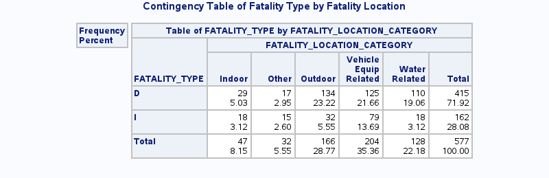

Figure 1: A contingency table showing fatality type by fatality location in 2019.

With this explanation aside, first consider the row totals, these statistics are related to the type of fatality. They show that weather events attributed to 415 direct and 162 indirect fatalities, or 72% and 28%, respectively. Most notably, deaths due to the direct forces of nature were significantly higher than indirect. The overall fatality statistic was 577.

Now consider the column totals in figure 1, these statistics are associated with the location of death. Most intuitively, being inside accounted for the least fatalities, only 8%. As expected, being outside had considerably more, with 29%. Positioning next to bodies of water appeared to be as dangerous with 22%. However, vehicle or equipment related deaths appeared to trump all others with 35%.

Lastly, consider the intersects of figure 1, these statistics provide information about the type of fatality and the location of death. Logically, being outside during a weather event had the most direct fatalities, owning 23% of the total and the most hazardous of all metrics. However, vehicle/equipment and water-based direct fatalities followed closely behind, with 22% and 19%, respectively. Indirect fatalities were their deadliest when linked with vehicle/equipment, accounting for 14% of the total metric and dwarfing all other locations of death.

Figure 2 shows the total direct and indirect injuries per month for weather events in 2019. Visual analysis suggests that weather events pose a greater risk to injury from January to July, but then drops considerably between August and December. The greatest risk of direct or indirect injury occurs in May or February, respectively. The safest months are January and October.

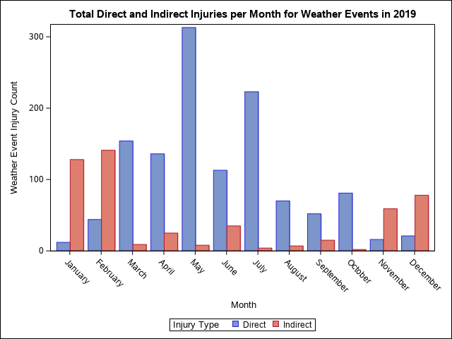

Figure 2: A clustered bar chart showing the total direct and indirect injuries per month for weather events in 2019.

To better understand the impact of storm events last year, it is appropriate to consider the effect that extreme phenomena may have had on property damage and human life. In this context, a two independent samples t-test has been carried out to test for a statistically significant mean difference in the cost of property damage, between tornado severity types EF0 and EF1, given;

*Null Hypothesis:* *H*<sub>0</sub> = 0,  
*Alternative Hypothesis:* *H*<sub>A</sub> ≠ 0,  
*Sample Size EF0:* *N*<sub>EF0</sub> = 644 > 30,  
*Sample Size EF1:* *N*<sub>EF1</sub> = 531 > 30,  
*Significance level:* *α* = 0.01.

Consider figures 3 and 4 below showing kernels of each sample against a theoretical normal distribution and Q-Q plots to check the normality assumption.

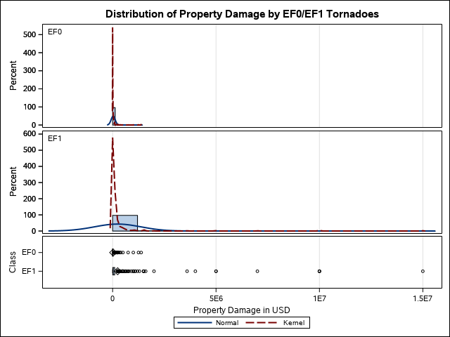

Figure 3: Distribution curves of the EF0 and EF1 kernels against the normal distribution  
with actual data points for both types below.

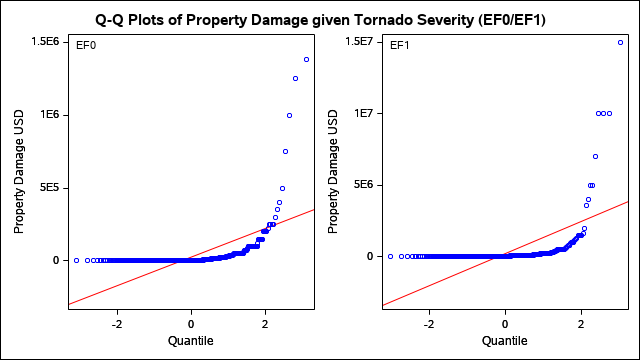

Figure 4: Q-Q plots show the distributions of tornado types plotted against theoretical normal quantiles.

In figure 5 below, the *p*-value for the test of homogeneity of variance is *p* < .0001, so *H*<sub>0</sub> was rejected at the 99% confidence level and equal variances was not assumed. Using the Satterthwaite (Welch) method for a two samples *t*-test found a statistically significant mean difference in property damage between tornado severity EF0 and EF1 of -$216,579, where *t* (df = 536.81) = -4.46, *p* <.0001 99% [-$342,058 -$91,101].

Put simply, the average cost of property damage during a EF1 tornado event is significantly greater than an EF0 tornado event. The average difference in the cost of property damage between these two types is $216,579. This variation quantifies the differences in destructive power.

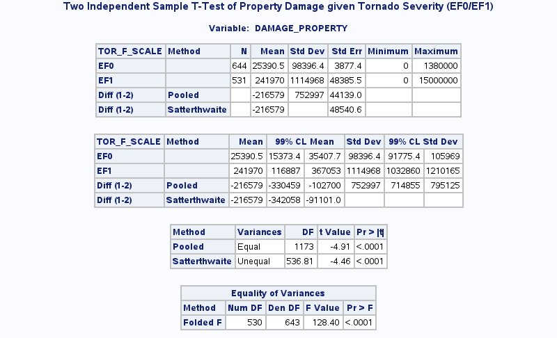

Figure 5: A summary of the two independent samples t-test of property damage given tornado type. Also shown is the test for equality of variances.

Figure 6 below shows the frequencies and percentages of different tornado types last year. Overall, there were a total of 1728 tornado occurrences, with 78% being EF0 or EF1. The difference in numbers between these types is only 117.

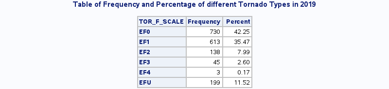

Figure 6: A frequency distribution table with percentage of different tornado types in 2019.

Now observe figure 7 below, the total damage caused by all tornadoes in 2019 far exceeds any other weather event classification with $3B in total damage. A crude method to gauge the contribution towards this total is to multiply the average cost of a single occurence (taken from figure 5) by the total number of occurences.

*Mean<sub>EF0</sub> x *N*<sub>EF0</sub>:* $25,391 x 730 = $18.54M  
*Mean<sub>EF1</sub> x *N*<sub>EF1</sub>:* $241,970 x 613 = $148.33M

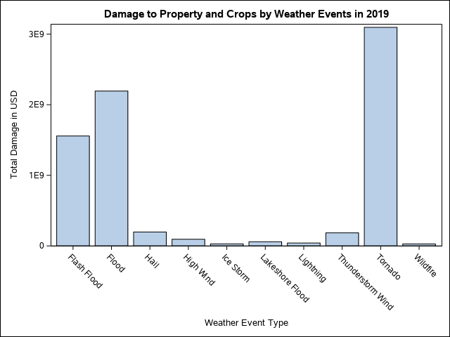

Figure 7: A bar chart showing damage cost to property and crops caused by weather events in 2019.

Another way to ascertain the effect that storm events had in 2019 is to measure the overall impact on human life. Consider figure 8 below, the impact coefficient has been created to measure the effect of such events and is defined as follows:

$$\begin{equation}
\tag{1}
I_{\alpha} = \sum_{i} \frac{ f_{\alpha} + t_{\alpha} } { f_{i} + t_{i} }
\end{equation}$$

Where *I*<sub>α</sub> is the impact coefficient, *f*<sub>α</sub> are the total fatalities (direct and indirect), and *t*<sub>α</sub> are the total injuries (direct and indirect) of any particular weather event type α. In the denominator, these variables are summed through *i* weather event types. Figure 8 reveals the overall impact on human life due to tornadoes last year was 0.6. This surpasses all other weather events overwhelmingly, as the remaining fall short of 0.1. Also below, figure 9 reveals an impact coefficient of approximately 0.5 in Alabama, this exceeds all other states. Therefore, one can infer that tornadoes had the highest impact on human life in the state of Alabama.

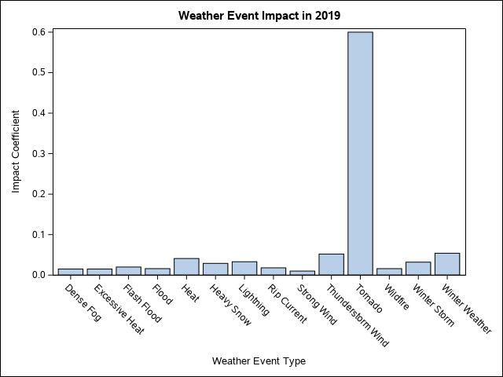

Figure 8: A bar chart showing impact coefficient given weather event type.

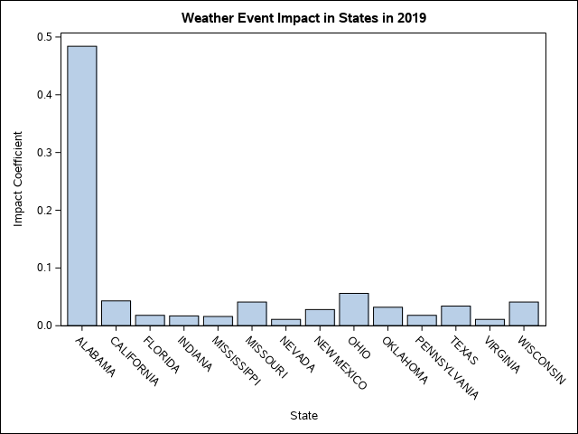

Figure 9: A bar chart showing impact coefficient given state.

Figure 10 below shows fatalities according to weather event classification. Rip currents had the most fatalities and wildfires the least, approximately 60 and 5, respectively. Despite having the highest impact coefficient, tornadoes were not the deadliest.

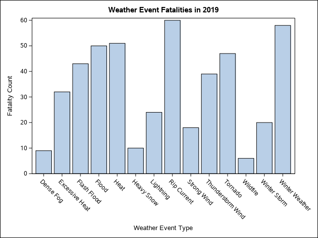

Figure 10: A bar chart showing fatalities given weather event type.

A similar situation in figure 11, where Alabama did not have the largest count of mortalities, despite yielding the highest impact coefficient. Instead, the highest concentration of fatalities is in California with around 60.

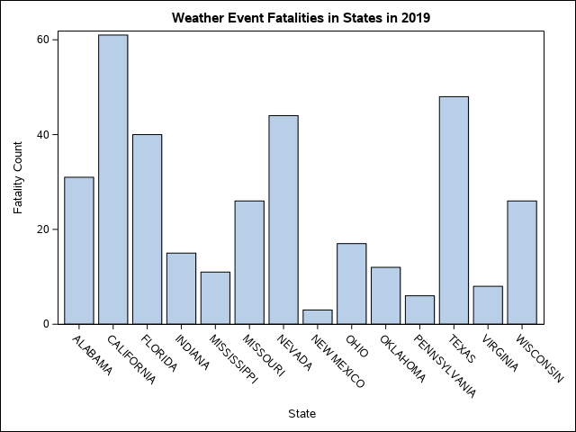

Figure 11: A bar chart showing fatalities given state.

# Conclusion

Weather events amassed 577 fatalities last year in the USA, with the majority not inside and due to direct exposure. A visual analysis revealed the months of greatest risk being from January to July. Of particular interest is the effect of storm events, as these categorise some of the most extreme phenomena, such as tornadoes.

Despite not having the most fatalities with respect to other weather event types, tornadoes clearly had the most significant effect on human life overall. This is prominently shown in terms of impact coefficients and damages caused. Based upon the analysis, Alabama appears to have been the most severely affected.